# Lab 11: Vibe Coding

CMSC471: Introduction to Information Visualization (Spring 2026)

**Grade (3% of total course grade)**: This lab is graded out of 30 points. You may submit your lab in person during the lab session on April 22, 2026 or during any office hours. The final submission deadline is April 30, 2026 at 6:00 PM (ET).

**Submission**: (1) the in-class checkout (2) the folder and chat history as a `.zip` (or similar) to Canvas!

In 2025, Andrej Karpathy (one of the founders of OpenAI) coined the term **“vibe coding”**: the practice of describing what you want in natural language and letting an AI write the code while you steer by feel, test, and iterate. It’s not about abandoning programming knowledge. It’s about a different relationship with code: one where you spend more time on *what* and *why*, and less time on *how to type it*.

Today, that’s what you’ll do. You’ll use an AI coding tool to build a D3.js visualization from scratch, **without writing most of the code yourself**. Along the way, you’ll learn what these tools are good at, where they fall short, and how to prompt them effectively.

This space is moving extremely fast. New tools and model versions are releasing every few weeks. The specific products listed below are current as of this writing (March 2026), but some details (pricing, free tiers, model names) may have already changed.

**Fumeng: I’ve come to accept that lab numbering is my true weakness: it’s Lab 11 on the syllabus, and Lab 13 in the instructions. Numbers don’t matter in grading…**

## Part 1: AI Coding Tools

Before we dive in, let’s take a brief look at what’s out there.

You may already be familiar with using AI through a **chat interface** (ChatGPT, Claude.ai, or similar). That works fine for isolated questions (or if you give it very detailed instructions), but it’s not the most effective approach for coding. You end up copy-pasting code back and forth, the AI can’t see your files directly, and context gets lost quickly.

The tools below are purpose-built for coding. They live where the code lives, can read and edit your files, and iterate without you shuttling text around. The ecosystem is evolving fast, but the main categories are:

### Terminal-based agents

These tools run in your terminal alongside your codebase. You describe a task, they read your files, write code, run commands, and iterate, all without leaving the command line.

**Claude Code** (by Anthropic) is the tool used to help build some of the labs you’ve been working through this semester. You give it a task in plain language, it reads the relevant files, writes or edits code, and explains its reasoning. It’s particularly good at multi-step tasks across multiple files.

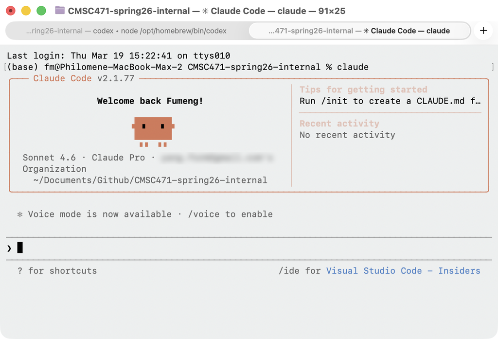

Claude Code running in the terminal.

**OpenAI Codex CLI** is OpenAI’s equivalent.

Both of these are powerful but have a small barrier to entry (setup, terminal comfort). We won’t use them hands-on today, but knowing they exist matters.

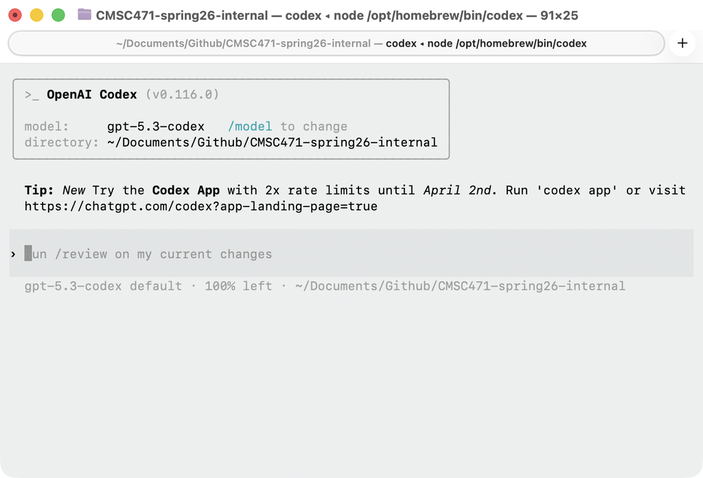

Codex CLI in action.

### IDE-integrated tools

These embed AI directly into your code editor, so you get suggestions, chat, and whole-file rewrites without switching context.

**Cursor** is a fork of VS Code with AI built deeply into the interface. It has a free tier that gives you a meaningful amount of usage each month. **This is what we’ll demo today. But you can use other tools if you’ve already set them up.** The paid version allows you to use different models (e.g., Claude, GPT).

**GitHub Copilot** is the widely deployed tool, integrated into VS Code, RStudio, and others. It requires a paid subscription (free for students via GitHub Education).

**Claude Code for VS Code** is Anthropic’s extension that brings the same Claude Code agent directly into VS Code. You can open it from the sidebar, ask it to read and modify files, and accept or reject changes without leaving the editor. It’s a good option if you already use VS Code and want Claude’s capabilities without switching to Cursor.

**Codex App** (by OpenAI) is a browser-based coding agent. You describe tasks in natural language and it generates or edits code in response, similar to the Codex CLI. It’s accessible at chatgpt.com/codex.

All of these tools share the same functions: they read your code and the broader context you give them, and they generate or modify code in response to natural language. The differences are in interface, model quality, context window size, and price 💵. For example, if you use Anthropic API, you may need to pay $4-6 per question with some of the models.

### Side bars

Agent `skills` are very useful for vibe coding. While we don’t teach it here, you are encouraged to check it out:

- [Cursor skills](https://cursor.com/docs/skills)
- [Claude code skills](https://code.claude.com/docs/en/skills)

## Part 2: Getting Started with Cursor

### Installation

1. Download Cursor from https://www.cursor.com and install it.
2. Open Cursor. It looks and feels like VS Code; all your extensions, keybindings, and settings can be imported.
3. Sign up for a free account when prompted. The free tier gives you 2,000 completions and 50 slow requests per month, more than enough for this lab. (**But perhaps save some of that for next lab!**)

### Open a project

First open your `CMSC471` folder using Open Project.

[figure not shown]

The landin page

### The interface

The basic mode is to ask in the chat panel on the right. You can ask it to read files, write new code, or explain what existing code does. If the chat panel appears empty or you get a model access error, look for a **Toggle Agents Window** button at the top of the panel and enable it. Agent mode allows Cursor to run terminal commands, create files, and iterate autonomously. Inside the panel, make sure **Agent** mode is selected at the top rather than “Ask” or “Edit” (you can try these later).

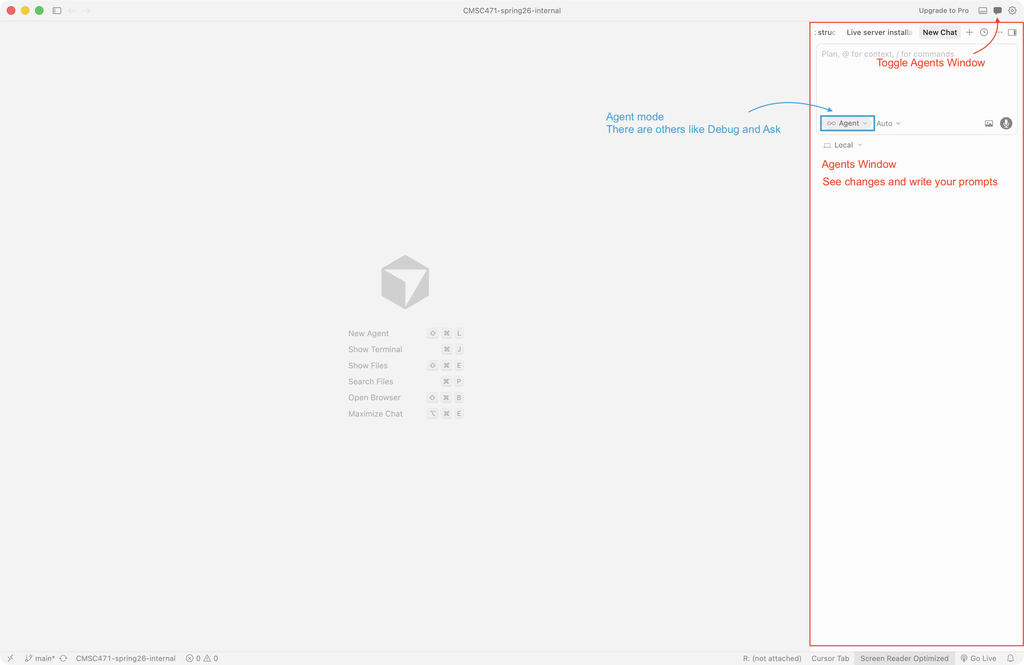

Cursor’s interface.

If you don’t see the file outline, toggle it open with the **Primary Side Bar** button (the leftmost icon in the activity bar, or View → Primary Side Bar).

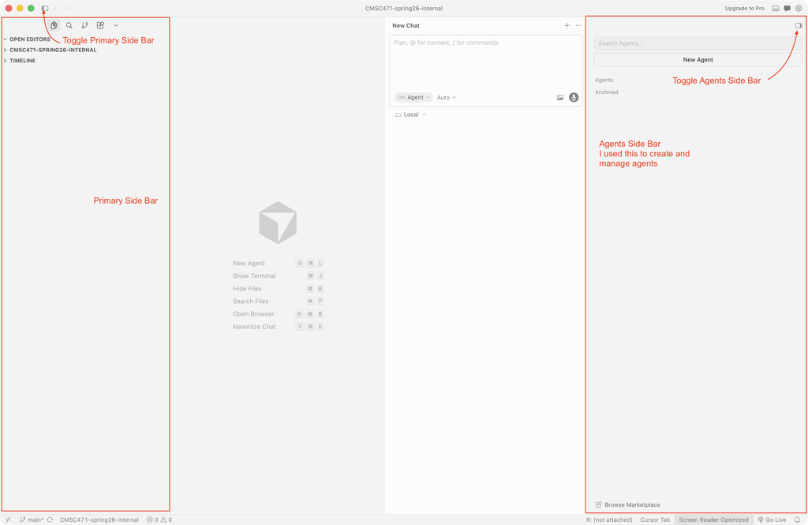

## Install Live Server

Next, install the **Live Server** extension. In the Extensions panel (Cmd+Shift+X), search for “Live Server” and install it. Technically, you can ask an agent to install this, but we choose to install it manually to make sure we get the same extension and avoid any hiccups with the agent installing the wrong one or not installing it correctly.

[figure not shown]

The Extensions panel in Cursor/VS Code.

Once installed, you’ll see a **Go Live** button in the bottom status bar. Click it to start a local server; your browser will open automatically and reload whenever you save a file.

[figure not shown]

The Go Live button in the status bar launches a local development server.

Leave the model selection on Auto for now.

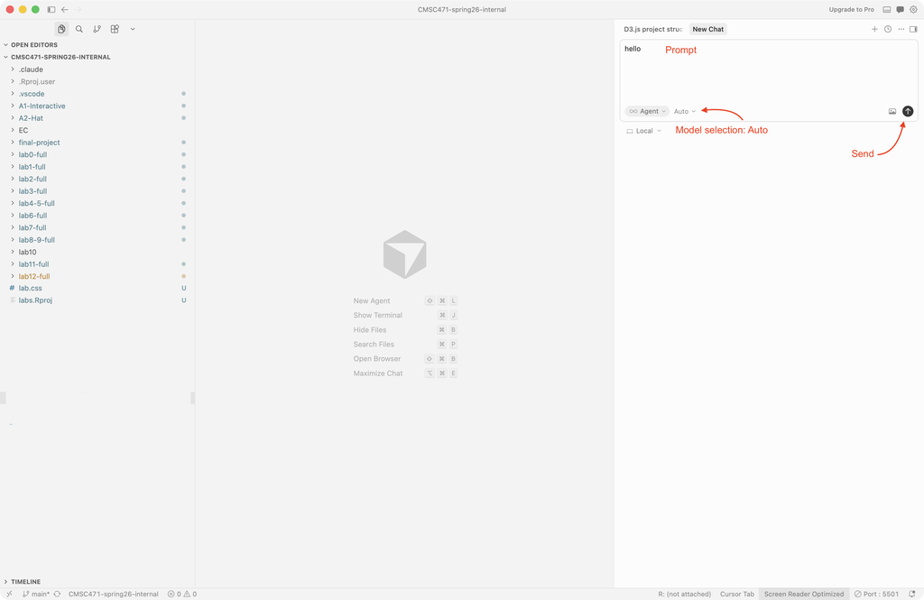

More explanation for the interface.

### Requirements

**You must use an AI coding tool, not a chat interface, to generate your code.** That means Cursor, Claude Code, Codex CLI, or an equivalent IDE-integrated or terminal-based agent. Simply copying code from Gemini, ChatGPT or Claude.ai does not count. The point is to experience the agentic loop: prompt → see the diff → accept or reject → iterate.

Your final work must include:

1. An SVG canvas with proper margins
2. A visual encoding that maps data to position, size, or color
3. At least one interactive feature (tooltip on hover, dropdown selector, slider, or clickable element)
4. A short paragraph (in `index.html`) explaining what the visualization shows and how to read it
5. A short note visible on the webpage (in `index.html`) stating that the code was largely AI-generated and naming the tool you used
6. A `reflection.md` file answering the four questions in Part 5

You decide the chart type, the visual encodings, and the story you want to tell.

### The dataset

Use any dataset from a previous lab:

- **Gapminder** (`gapminder_subset.csv` from lab 4-5): life expectancy, GDP, population by country and year
- **COVID cases** (`COVID_US_cases.csv` from lab 8-9): daily case counts by U.S. state

### Project structure

Before setting up the folder manually, let’s make the agent do it. Open Cursor’s Agent and type something like:

```
Create a new D3.js project called lab11-vibe with this structure:
- index.html with Bootstrap 5, a D3 v7 script, a #vis div, and a #tooltip div
- css/styles.css with a container
- js/script.js
- a data/ folder (empty for now)
```

Your output will depend on which model Cursor is using. The default model changes over time, and different models produce noticeably different results; some generate cleaner structure, some add more boilerplate. If the output isn’t quite what you wanted, you can either accept it and refine with follow-up prompts, or try being more specific upfront (e.g., “use a single script.js file only”). Even the same model and prompt can lead to different results.

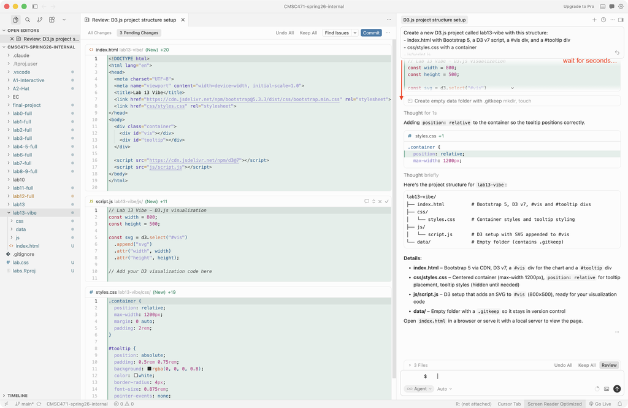

Review and accept the diffs Cursor proposes.

[figure not shown]

You’ll see a diff view showing every file the agent wants to create or modify. Review the proposed changes; you can accept all at once or step through file by file. It’s fine to accept without reading every line for now, but **you are responsible for the code you generate**. The AI wrote it; you need to own it.

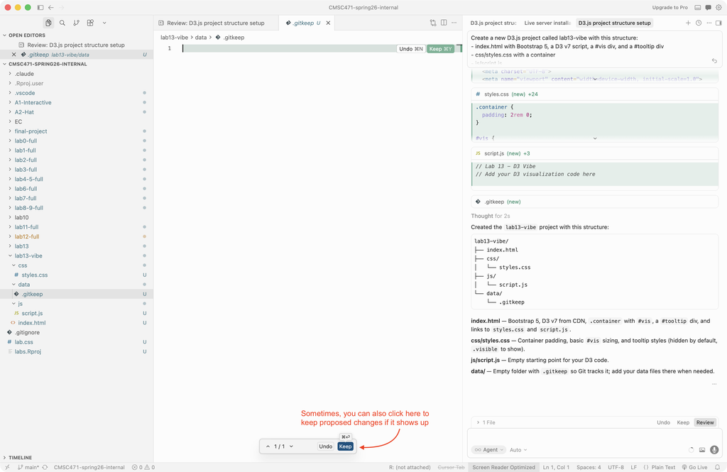

Remember to copy your dataset into `data/` (or you can try asking the agent to do so).

This is a good first test of what the agent can do. Notice how it handles multi-file creation and whether the output matches what you asked for. Your structure should look like:

```
lab11-vibe/
├── index.html
├── css/
│   └── styles.css
├── js/
│   └── script.js
└── data/
    └── your-dataset.csv
```

## Part 3: Start the server

Click **Go Live** in the status bar. Your browser should open to `http://localhost:5501/lab11-vibe/`. Right now the page is blank: that’s expected. A blank page with no errors means your HTML loaded fine; the canvas is just empty until you add D3 code.

Note: you can open a browser in Cursor. I still use an external browser in this handout because I have more than one monitor.

[figure not shown]

Open a browser in Cursor.

## Part 4: Prompting Strategies

Writing good prompts is a skill. And this heavily depends on how much you know about D3 and visualization.

### Start with context, then the task

The single most effective thing you can do is give the AI the full picture before the task. Without context (library version, file structure, what the data looks like), the model is guessing. With it, the first response is usually close to what you want.

Don’t just say “make a bar chart.” Take a moment to think what you want and give the AI the full picture upfront:

```
I'm building a D3.js v7 visualization in a browser project.
I have a CSV file at data/gapminder_subset.csv with columns:
country, continent, year, life_expectancy, income_per_person, population.

Set up an SVG canvas with margins, load the CSV, and draw a dynamic scatterplot:
- x axis: a chosen variable
- y axis: a chosen variable
- size: a chosen variable
- A slider to change years
- Three dropdown menus to choose x, y, z
```

That’s a much better starting point than “make a scatter plot of gapminder data.” You don’t need to specify every detail; most models will make reasonable choices for canvas size, margins, and colors. But if you have strong preferences, include them: code structure, specific colors, or a particular font size. The more opinionated your prompt, the less you’ll need to fix later.

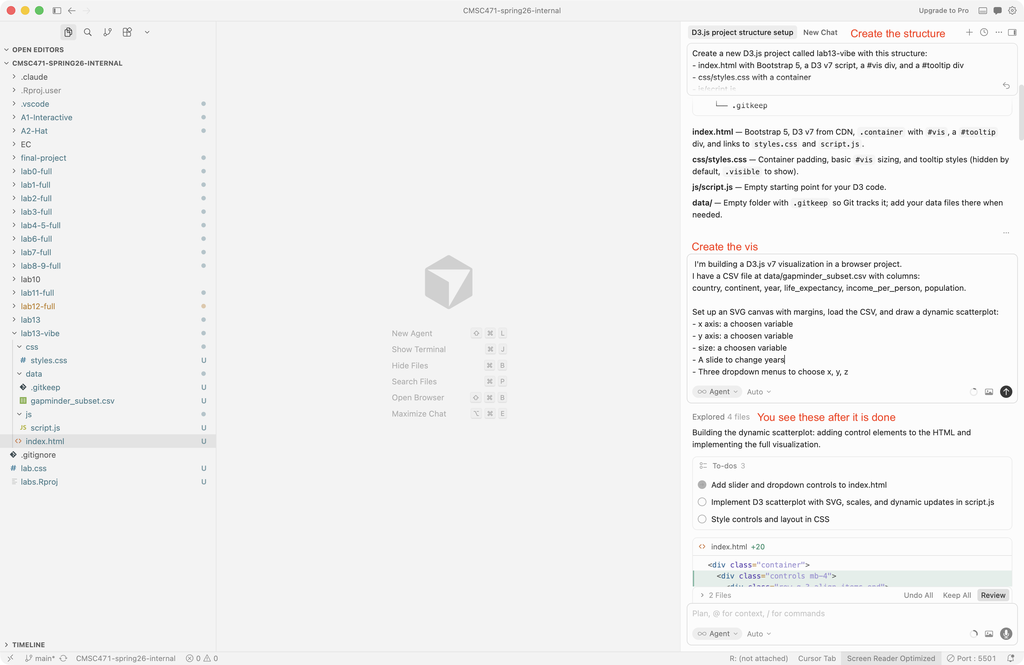

The full context prompt for a Gapminder scatterplot typed into Cursor’s agent panel.

### Review

When Cursor proposes a diff, you don’t have to review every line before accepting. For large changes, it’s often faster to accept all and then check the result in the browser.

Here’s what the first result looked like after I used the initial prompt above. Your output will likely look different depending on the model and how you phrased the prompt. Or simply, by chance.

Surprisingly, no console errors on my first try, but don’t assume that’s always the case. **Always check and test.** Also open the browser console and confirm there are no red errors before moving on.

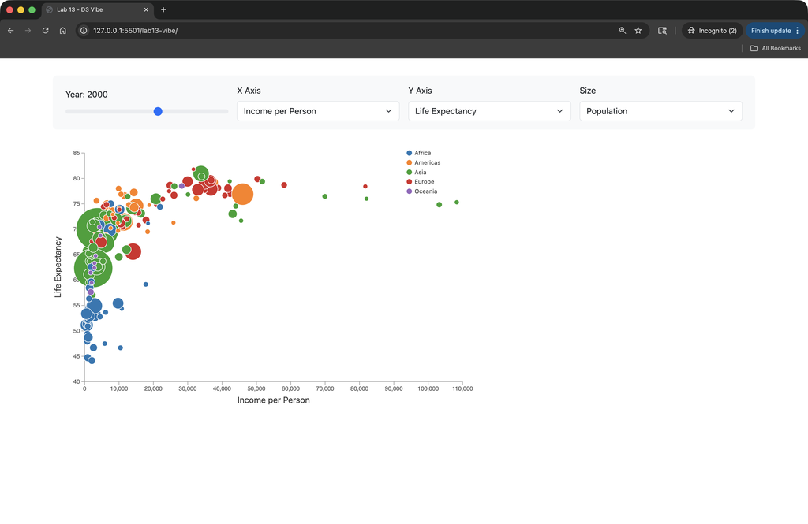

The first visualization result in the browser after I accepted proposed changes for the initial prompt.

If something breaks, you can revert a specific change. Small bugs can be fixed manually or by using another round of prompt.

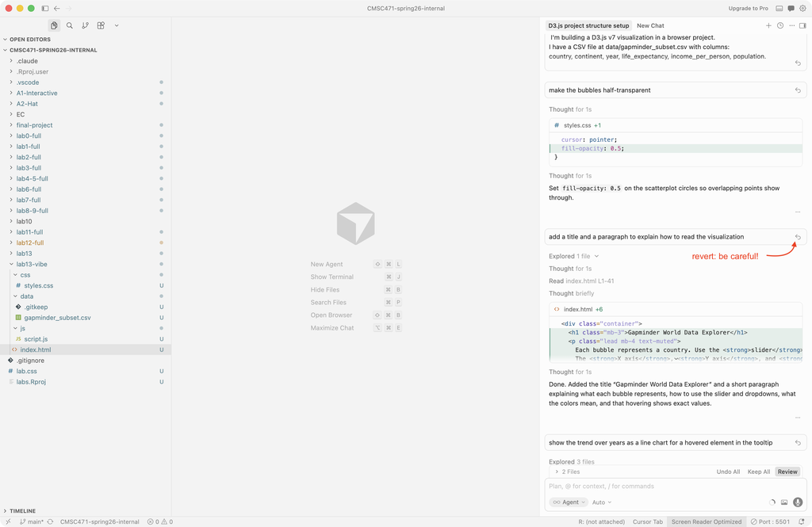

Cursor’s revert option lets you undo a specific agent change without losing unrelated edits.

### Iterate, don’t rewrite unless you have to

After the first result, make targeted follow-up prompts rather than asking it to redo everything. For example,

- “make the bubbles half-transparent”
- “add a title and a paragraph to explain how to read the visualization”

You don’t have to use these two prompts (see the requirements below)

### Give it your existing code

Cursor adds two main AI interactions on top of VS Code:

**Chat (Cmd+L)**: Opens a side panel where you can have a conversation with the AI about your code. You can reference specific files with `@filename`. This is good for asking questions, explaining code, and planning.

**Inline edit (Cmd+K)**: Highlight a block of code, press Cmd+K, describe what you want to change. Cursor rewrites just that selection. Good for targeted fixes.

For example, use `@script.js` in Cursor’s chat to reference your file directly. This saves you from copying and pasting and ensures the AI is working with the current version.

**Another useful trick**: copy a specific block of code and paste it directly into the chat with a question. This is faster than referencing the whole file when you only need help with a few lines. When debugging, starting a fresh agent chat (rather than continuing a long conversation) often gives better results; the model isn’t carrying the weight of earlier context. You can also try the “Debug” mode (Agent → Debug).

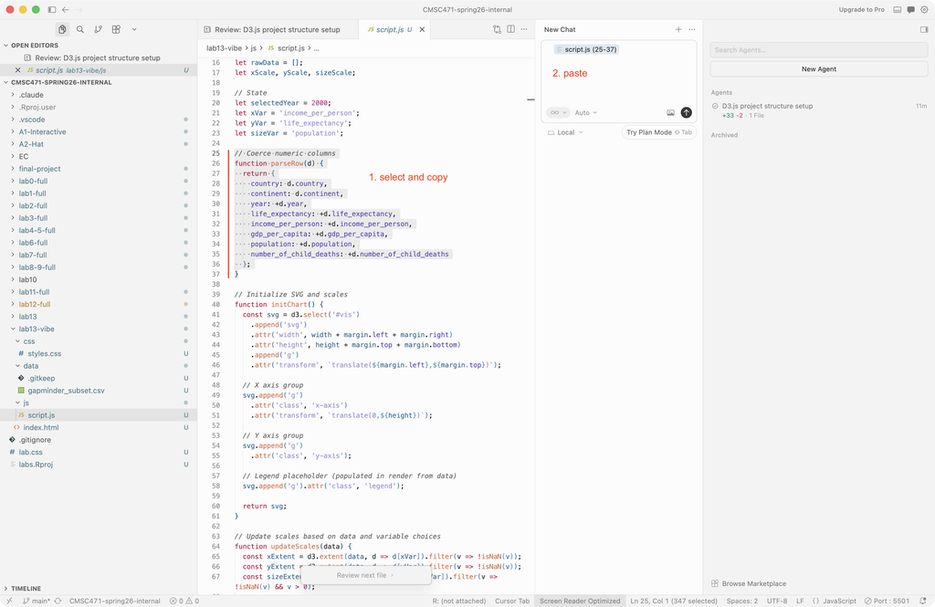

Pasting a specific code block into Cursor’s chat.

Another way to give it context is to select a block of code and add to chat.

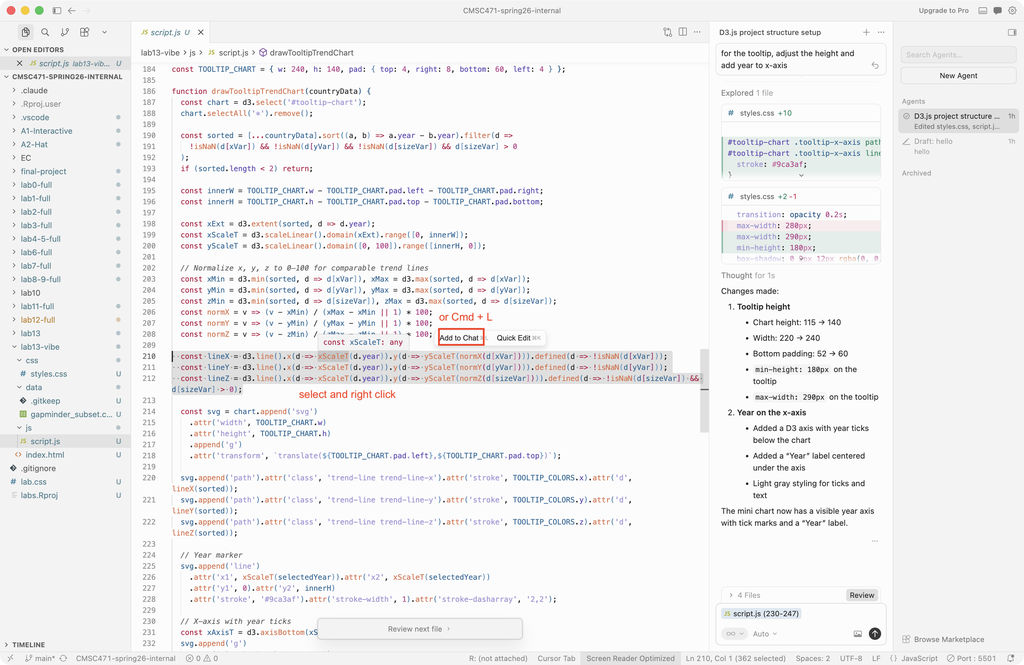

If you paste code with unusual formatting or very long lines, the AI may not parse the line numbers correctly, but it will usually still understand the logic.

For small, targeted fixes, there’s an even faster option: select a block of code in the editor, right click and describe the change. Cursor rewrites just that selection in place, with no diff panel to navigate.

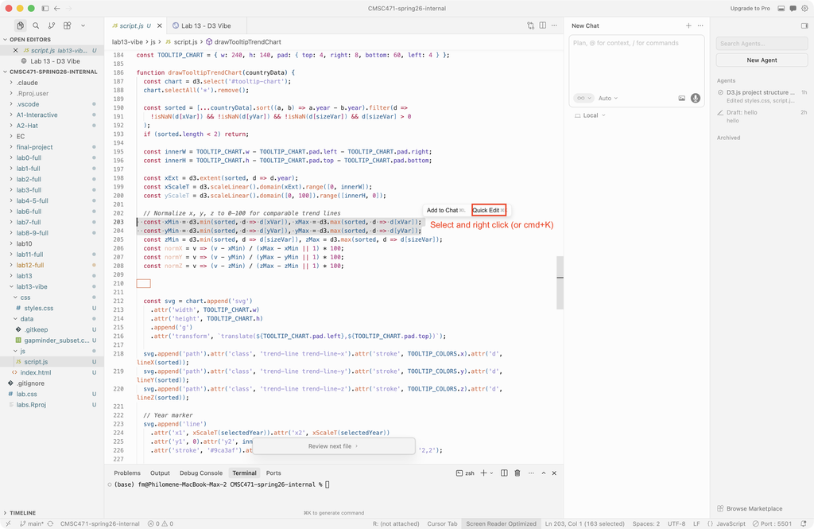

Selecting a block of code and pressing Cmd+K opens the inline edit bar.

### When to step in yourself

Not every fix needs a prompt. If the issue is a single wrong value (an axis label, a color, a margin) or when you know the exact problem, editing the file yourself is often faster than re-prompting and reviewing another diff. Model usage also has limits, so save your prompts for the things that are genuinely hard to type out.

Common cases where a manual edit is faster: wrong font size, off-by-one in a margin, a missing label, or a color you want to change to a specific hex value.

### Push it further: add one new feature

Once the core visualization is working, add one feature you didn’t plan from the start. It should be something that genuinely extends the visualization: not just a color change or a label. This is also the part of the lab where your D3 background matters most. Having built the previous labs yourself means you recognize what you can do and you can ask for it precisely (transitions, brushing, mini charts). Without that background, you don’t know what’s possible.

Think about what would make your chart more informative or more interesting to explore. Some ideas:

- A sparkline or mini-chart inside the tooltip showing a trend over time for the hovered element
- A “highlight on click” that mutes all other marks and brings one into focus
- An animated transition between two states (e.g., year changes, variable changes)
- A second linked view that updates when you interact with the first

Come up with your own if you have a better idea. For grading, this feature needs to **(1) work without errors, (2) add something meaningful to the visualization (not just changing colors or font size), and (3) not replicate the instructor examples (no credit for replicating :P).**

Here’s an example of what one such extension looks like (the nicer tooltip):

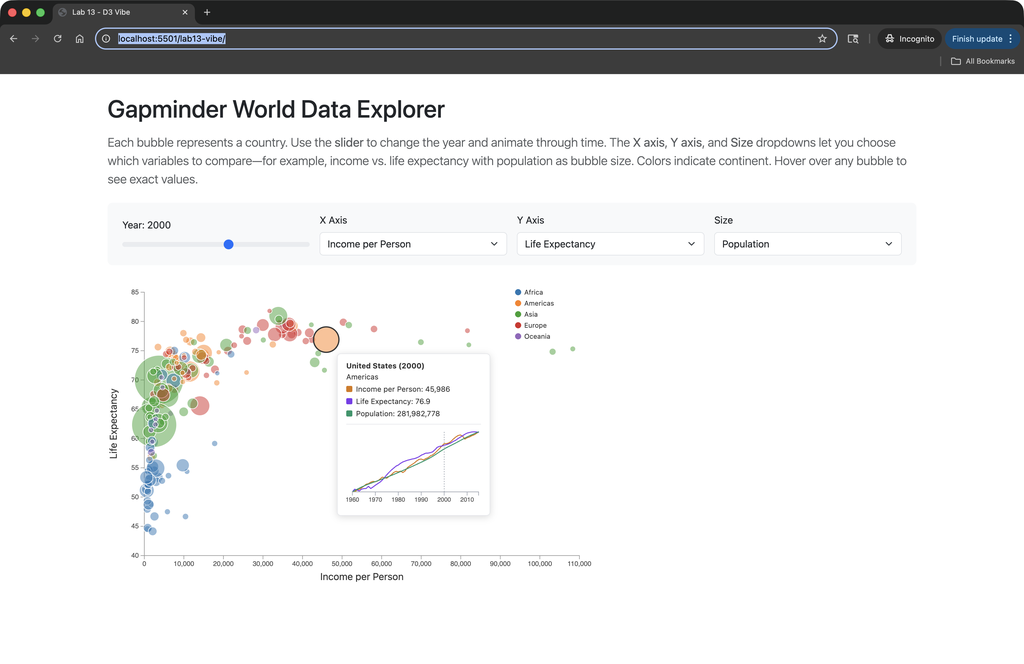

Demo of new features.

### Add an AI disclaimer

Once you’ve added the AI disclaimer note to the page, you’re done with the main build!

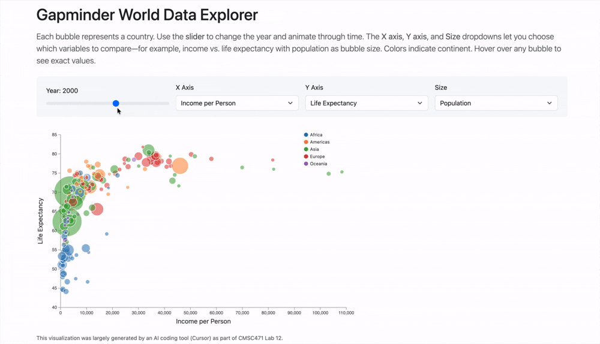

Final demo.

## Part 5: Reflection

After finishing your visualization, take a few minutes to answer these questions:

1. **What went well?** Where did the AI save you significant time or solve something you might have struggled with?
2. **What required manual fixes?** List at least two things you had to correct yourself, and explain what was wrong.
3. **How did your prompts evolve?** Paste your first prompt and your last prompt for the same feature, and describe what changed.
4. **Your take**: In one or two sentences, how do you see yourself using tools like this in future visualization work?

## Checklist ✓

A working D3.js visualization loads in the browser with no console errors.  
At least one interactive feature is working (tooltip, selector, slider, etc.).  
One new feature added beyond the initial prompt, works correctly and adds something meaningful.  
A paragraph in `index.html` explains the data and how to read the visualization.  
`reflection.md` is complete with answers to all four questions in Part 5.  
The visualization was built using an AI coding tool (Cursor, Claude Code, Codex, or equivalent), not a chat interface or by hand.  
Make sure you have your AI disclaimer.  
Export the main chat history from your AI tool and include it in your project folder (e.g., `cursor-chat-history.md`).

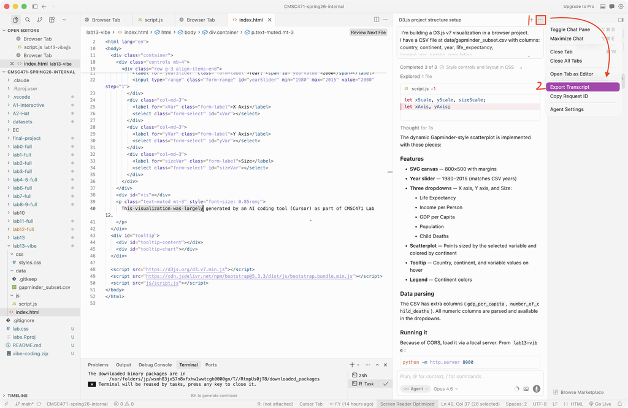

How to export a chat history

## Submission process

**Note**: We will assign scores **after you’ve completed both**: (1) in-person or Zoom checkout and (2) Canvas submission for the project.

**In-person checkout** (during lab or office hours):

- Raise your hand ✋
- Show the working visualization in the browser
- Show us your project folder and one prompt-response exchange that you found interesting
- Confirm your name

**Canvas submission**: Zip your `lab11-vibe/` folder (including the chat history `cursor-chat-history.md`, `index.html`, `css/`, `js/`, `data/`, and `reflection.md`) and upload it to Canvas by the deadline.

## AI usage

You must use an AI coding tool to generate code for this lab. Cursor, Claude Code, and others all qualify. The only constraint is that **the AI tool must be generating and editing the code in your editor**, not a chat interface where you copy-paste, and not by writing most of the code yourself 😬.

- The **reflection** must be written by you and based on your actual experience during this lab session.
- You must be able to **show your prompt history** at checkout.
- Copying a visualization you didn’t generate yourself (e.g., from Observable) does not count.

## Resources

- [Cursor documentation](https://docs.cursor.com)
- [Karpathy on vibe coding](https://x.com/karpathy/status/1886192184808149383)
- Casino vs Vibe coding